# Tutorial 1 - Intro to R, Rstudio and RMarkdown; Basic Data Exploration and Manipulation

Zachary Binney, PhD

August 2023

## R vs. RStudio vs. RMarkdown

**R** is the actual programming language we’ll be using. It was developed specifically for data analysis and statistics. Other languages you may be familiar with, like C++ or Java, are more “general purpose” languages that do a broader set of computer-y things but aren’t as specialized or easy to work with for data analysis and statistics.

**RStudio** is an interface for using R. It makes programming in R much more pleasant but isn’t technically *necessary* to program in R.

**RMarkdown** is probably the most confusing of the three. It’s a way of using a language called “Markdown” alongside R code, in the RStudio interface, to create pretty reports, presentations, and other documents that interweave your code, graphics, and explanatory text. In other words, it’s a great way to communicate your work to a broader audience.

It’s what I used to produce this document you’re reading. It’s also how you will submit your labs/homework.

### R Scripts vs. RMarkdown

You can just write R code with written comments in an R “script” (a file of code that ends `.R`). The pro is this is “lightweight” - it has only code and comments, nothing extraneous. If you’re doing straight programming or software development, this is what you’d use.

RMarkdown, as noted above, interweaves code blocks and comments with explanatory text, tables, and graphs. It also lets you format all of the above (for example, bold and italicize text or create bulleted lists). This is great for creating any documents, such as analytical reports, you want to share with colleagues or managers. RMarkdown creates a `.Rmd` file that is then “**knit**” to a format for sharing such as HTML (which will appear like a webpage in any web browser) or PDF.

**Lab Activity 1**: The easiest way to understand the difference between a **script** and an **RMarkdown document** is to look at two side-by-side, which we’ll do now. If you’re not in class, you can compare the files `RMarkdown_example.Rmd` and `R_script_example.R` on Canvas.

## Basic R Programming

### RStudio Layout

It will be helpful to start with a map of what happens when you open a .R file (some code) in RStudio. Here’s a tour of the basic areas:

[figure not shown]

*RStudio when you open a code script.*

1. The **Console**. This is where you can type some code and, as soon as you press “Enter,” it runs once. We’ll talk more about its uses in a moment.
2. **Scripts**. These are .R, .Rmd, or other files of code and text that you write and save, just like a Word document. You can run them over and over again. We’ll talk more about this in a moment, too.
3. **Environment**. There are several **tabs** here, but the most relevant one is “Environment.” This lists **objects** specific to your current R session - we’ll cover these in a moment.
4. A miscellaneous window. There are a few important things in this pane:
   1. **Files** - this lists the files and folders in your **working directory** (typically, where the script you’re working in is located). I don’t use it all that often to be honest.
   2. **Plots** - when you create a plot by running code in a **script**, this is where it shows up (it will show up in-line in the RMarkdown document if you produce it there).
   3. **Packages** - this is the list of R **packages** (bits of code that do extra stuff) you have installed on your machine. More on them below.
   4. **Help** - I end up here all the time. When you need to look up details about how to do something in R, you can type `?[function_name]` in the **Console** and it will pull up information here. For example, try typing `?sum` into your **Console** and see what pops up.

Now that you’ve got the lay of the land, let’s talk about how you can run code in R.

### What is R code?

“R code” - or any computer code - is basically text asking your computer to do something. It’s a set of instructions. In the same way that I might ask you to stand up, walk over to the bathroom, and wash your hands, I could write some text in a very specific format to tell R “add 1 + 1, then assign that value to a variable called `x`, and store that result somewhere.”

R is **CASE-SENSITIVE**. A very, very common reason your code doesn’t run properly is because you accidentally messed up the capitalization of a function name, dataset name, variable, etc. Always be aware of this possibility!

### Some very basic R code examples

#### Arithmetic

Probably the easiest thing to start with in R is to treat it like a big calculator - which you already did in Tutorial 0.

Here’s R doing some basic arithmetic.

```r
#This is static code and output in RMarkdown.  This green text is a "Comment" that is not run as code.

2+7
```

```
## [1] 9
```

In RMarkdown, `R code is displayed in a grey box like this`, and R’s answer after running that code appears in a box with a white background.

#### Creating Objects

R holds information in things called **objects**. An **object** could be a data frame, or instructions for a function, or a single numerical value, or a plot, or a ton of other things.

Here’s R creating an object called `x` that it assigns the value 2. The way you “give” an “object” a “value” is to use the **assignment operator** `<-`. Pro tip: use the keyboard shortcut `Alt + minus sign`.

```r
x <- 2

x
```

```
## [1] 2
```

The easiest way to translate the below code into English is “x gets 2” or “x receives 2”. Once you’ve assigned a value to an object, R will remember that and you can use that object for other actions later. For example, what do you think the below code will return? Run it in your own R Console and see if you’re right!

```r
x <- 2

x + 35
```

### R Cheatsheets

Before we move on I want to introduce you to R [Cheatsheets](https://rstudio.com/resources/cheatsheets/). These are incredibly useful summaries of tips and tricks for various common topics in R. The easiest way to access them is going to `Help` > `Cheatsheets`.

Try opening the one for RMarkdown now!

### Common Errors in R

I also want to introduce you to [this *excellent* guide](https://nickch-k.github.io/DataCommSlides/Lecture_04_Common_R_Problems.html#things-breaking) from Nick Huntington-Klein at Seattle University. It lists some good general troubleshooting strategies; common error messages, what the typical sources of those are, and how to fix them; and common mistakes students make when learning R.

It probably will not make a lot of sense to read proactively right now, but it is a GREAT first step when you encounter an issue you don’t recognize.

### Packages

As you’ve already learned, packages are bits of standalone code, written by others, that when **installed** (and **loaded**) allow R to do different things it couldn’t before.

Most often these add one or more new **functions** (actions that take an input and produce an output) to those R knew before. Sometimes packages also add **objects** such as new datasets or color palettes - for example, the `Lahman` package is going to give us the baseball data we’ll work with below.

To use a package you have to **install** it once and **load** it every time you open a new R session. A good analogy for all this is a lightbulb. To get light you have to do two things: screw in the bulb, and flip a switch on. Installing a package is like screwing in the bulb - you only have to do it once, and it’s there for you in the future. Loading it is like flipping the lightswitch - you have to do this every time you want the light.

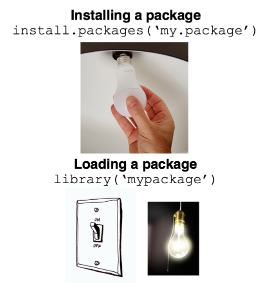

*Installing vs. loading a package*

The easiest way to do all this is with the `pacman` package, which automates a lot of the work.

**Lab Activity 2**: Open an R script, save it as `SiS_Lab_1`, and add this code to it, and run by placing your cursor in the line and hitting `Ctrl/Cmd + Enter` to install and load the `Lahman` package:

```r
#This code loads the Lahman and tidyverse package, but installs either one first IF AND ONLY IF you don't already have it installed

pacman::p_load(Lahman, tidyverse)
```

Now we’re all ready to use the `Lahman` package.

Sidenote: why did we use the `::` above? To access the `p_load()` function from the `pacman` package without bothering to load `pacman` separately, we needed to use this syntax.

## Baseball Data!

OK, time for the fun stuff. I hope, anyway.

### Exploring New Datasets

There are a number of ways to get data into R, but the process can be a bit tedious so we’re going to skip that for now. Instead we’re going to make use of datasets - called **data frames** in R-speak - that we’ve already loaded into R via the `Lahman` package.

To see a list of the available datasets, run the code `?Lahman` in your **Console** to view the package help page.

We’re going to be working with the `Teams` data frame. First we should load it so we can see it in Environment pane:

**Lab Activity 3**: Add all code below to your script as we go.

```r
# Show Teams data in environment pane
data(Teams)
```

Then to explore a data frame I usually first try clicking on it in my environment pane (or, alternatively but less desirably in my opinion, typing `View(Teams)` in my Console). If you’ve ever looked at an Excel spreadsheet this should feel familiar, which is why I find it a good place to start - at least before you get more R experience.

Then I usually like to use the following functions from the `tidyverse` package:

```r
# Print first 6 rows of data
head(Teams)
```

```
##   yearID lgID teamID franchID divID Rank  G Ghome  W  L DivWin WCWin LgWin
## 1   1871   NA    BS1      BNA  <NA>    3 31    NA 20 10   <NA>  <NA>     N
## 2   1871   NA    CH1      CNA  <NA>    2 28    NA 19  9   <NA>  <NA>     N
## 3   1871   NA    CL1      CFC  <NA>    8 29    NA 10 19   <NA>  <NA>     N
## 4   1871   NA    FW1      KEK  <NA>    7 19    NA  7 12   <NA>  <NA>     N
## 5   1871   NA    NY2      NNA  <NA>    5 33    NA 16 17   <NA>  <NA>     N
## 6   1871   NA    PH1      PNA  <NA>    1 28    NA 21  7   <NA>  <NA>     Y
##   WSWin   R   AB   H X2B X3B HR BB SO SB CS HBP SF  RA  ER  ERA CG SHO SV
## 1  <NA> 401 1372 426  70  37  3 60 19 73 16  NA NA 303 109 3.55 22   1  3
## 2  <NA> 302 1196 323  52  21 10 60 22 69 21  NA NA 241  77 2.76 25   0  1
## 3  <NA> 249 1186 328  35  40  7 26 25 18  8  NA NA 341 116 4.11 23   0  0
## 4  <NA> 137  746 178  19   8  2 33  9 16  4  NA NA 243  97 5.17 19   1  0
## 5  <NA> 302 1404 403  43  21  1 33 15 46 15  NA NA 313 121 3.72 32   1  0
## 6  <NA> 376 1281 410  66  27  9 46 23 56 12  NA NA 266 137 4.95 27   0  0
##   IPouts  HA HRA BBA SOA   E DP    FP                    name
```

[output cut: 20 more lines]

```r
# Show "structure" of data - including dimensions (rows and columns), variables, and variable types
str(Teams)
```

```
## 'data.frame':    3015 obs. of  48 variables:
##  $ yearID        : int  1871 1871 1871 1871 1871 1871 1871 1871 1871 1872 ...
##  $ lgID          : Factor w/ 7 levels "AA","AL","FL",..: 4 4 4 4 4 4 4 4 4 4 ...
##  $ teamID        : Factor w/ 149 levels "ALT","ANA","ARI",..: 24 31 39 56 90 97 111 136 142 8 ...
##  $ franchID      : Factor w/ 120 levels "ALT","ANA","ARI",..: 13 36 25 56 70 85 91 109 77 9 ...
##  $ divID         : chr  NA NA NA NA ...
##  $ Rank          : int  3 2 8 7 5 1 9 6 4 2 ...
##  $ G             : int  31 28 29 19 33 28 25 29 32 58 ...
##  $ Ghome         : int  NA NA NA NA NA NA NA NA NA NA ...
##  $ W             : int  20 19 10 7 16 21 4 13 15 35 ...
##  $ L             : int  10 9 19 12 17 7 21 15 15 19 ...
##  $ DivWin        : chr  NA NA NA NA ...
##  $ WCWin         : chr  NA NA NA NA ...
##  $ LgWin         : chr  "N" "N" "N" "N" ...
##  $ WSWin         : chr  NA NA NA NA ...
```

[output cut: 34 more lines]

```r
# Provide a summary of each variable in the data frame
summary(Teams)
```

```
##      yearID     lgID          teamID        franchID       divID
##  Min.   :1871   AA:  85   CHN    : 147   ATL    : 147   Length:3015
##  1st Qu.:1923   AL:1310   PHI    : 140   CHC    : 147   Class :character
##  Median :1968   FL:  16   PIT    : 136   CIN    : 141   Mode  :character
##  Mean   :1959   NA:  50   CIN    : 133   PIT    : 141
##  3rd Qu.:1997   NL:1534   SLN    : 131   STL    : 141
##  Max.   :2022   PL:   8   BOS    : 122   PHI    : 140
##                 UA:  12   (Other):2206   (Other):2158
##       Rank              G             Ghome             W
##  Min.   : 1.000   Min.   :  6.0   Min.   :24.00   Min.   :  0.00
##  1st Qu.: 2.000   1st Qu.:154.0   1st Qu.:77.00   1st Qu.: 66.00
##  Median : 4.000   Median :159.0   Median :81.00   Median : 77.00
##  Mean   : 4.028   Mean   :150.1   Mean   :78.08   Mean   : 74.67
##  3rd Qu.: 6.000   3rd Qu.:162.0   3rd Qu.:81.00   3rd Qu.: 87.00
##  Max.   :13.000   Max.   :165.0   Max.   :84.00   Max.   :116.00
##                                   NA's   :399
##        L             DivWin             WCWin              LgWin
##  Min.   :  4.00   Length:3015        Length:3015        Length:3015
##  1st Qu.: 65.00   Class :character   Class :character   Class :character
##  Median : 76.00   Mode  :character   Mode  :character   Mode  :character
##  Mean   : 74.67
##  3rd Qu.: 87.00
##  Max.   :134.00
##
##     WSWin                 R                AB             H
##  Length:3015        Min.   :  24.0   Min.   : 211   Min.   :  33
##  Class :character   1st Qu.: 614.0   1st Qu.:5142   1st Qu.:1297
##  Mode  :character   Median : 691.0   Median :5405   Median :1389
##                     Mean   : 681.2   Mean   :5132   Mean   :1339
##                     3rd Qu.: 764.0   3rd Qu.:5519   3rd Qu.:1464
##                     Max.   :1220.0   Max.   :5781   Max.   :1783
##
##       X2B           X3B               HR              BB
##  Min.   :  1   Min.   :  0.00   Min.   :  0.0   Min.   :  0.0
##  1st Qu.:195   1st Qu.: 29.00   1st Qu.: 47.0   1st Qu.:427.0
##  Median :234   Median : 40.00   Median :111.0   Median :494.0
##  Mean   :229   Mean   : 45.43   Mean   :106.5   Mean   :473.6
##  3rd Qu.:272   3rd Qu.: 58.00   3rd Qu.:156.0   3rd Qu.:554.0
##  Max.   :376   Max.   :150.00   Max.   :307.0   Max.   :835.0
##
```

[output cut: 41 more lines]

```
##  Length:3015        Min.   :      0   Min.   : 60.0   Min.   : 60.0
##  Class :character   1st Qu.: 544782   1st Qu.: 97.0   1st Qu.: 97.0
##  Mode  :character   Median :1203014   Median :100.0   Median :100.0
##                     Mean   :1385100   Mean   :100.2   Mean   :100.2
##                     3rd Qu.:2080399   3rd Qu.:103.0   3rd Qu.:103.0
##                     Max.   :4483350   Max.   :129.0   Max.   :141.0
##                     NA's   :279
##    teamIDBR         teamIDlahman45     teamIDretro
##  Length:3015        Length:3015        Length:3015
##  Class :character   Class :character   Class :character
##  Mode  :character   Mode  :character   Mode  :character
##
##
##
##
```

Finally, since this data is part of a package in R, run `?Teams` to get to the help page for the data frame while looking at everything else. This provides a sort of **Data Dictionary** to help you decode what you’re seeing. (Note if the data you’re using isn’t part of a package you may need some other external data dictionary to explain what you’re seeing.)

**Lab Activity 4**: Use what we did above to answer the following questions about the data frame:

1. How many rows are there?
2. How many columns are there?
3. What do you think each row represents?
4. What does the `H` column in row 2,182 represent, in words?

### Rectangular Data

Much of the data you’ll work with in sports - though by no means all! - is **rectangular data**. This is all we’ll be working with in this course.

Rectangular data is like an Excel spreadsheet. It’s organized into rows and columns. Each row can be considered an **observation** with values for a bunch of different **variables**. These variables are the columns.

For example, in `Teams` each row is a “team-season” (one team in one season), with a bunch of different performance data for those team-seasons in the columns.

### Basic Data Manipulation

There are 5 basic tasks I want to show you how to do in R. But first I have to introduce you to a new concept that will make all this easier: the pipe, written `%>%` but most easily entered using the shortcut `Ctrl/Cmd + Shift + M`.

#### The Pipe

The pipe lets us “chain” multiple functions together. The easiest way to understand it for now is to read it as `Take This Thing/Result Before the Pipe, Then (%>%) Do This Thing After The Pipe To It`. The pipe is the “then” in that sentence. Examples follow below.

#### Choosing Rows That Fit Criteria Using `filter()`

Say we want to get a data frame of teams from *just* the 2022 MLB season. We can do it using the `filter()` function:

```r
# Create a new data frame with just the 2022 MLB season
teams_2022 <- Teams %>% # Take the Teams data frame, THEN
  filter(yearID == 2022) # Filter to only rows where the yearID variable, which indicates season, equals 2022
```

Note to check if some value or variable equals some other value or variable we have to use `==`, not `=`! You *will* screw this up more than once. It’s OK!

**Lab Activity 5**: Now inspect the new data frame, and print its first 6 rows using `head()`.

1. What do you see at the top? Is it different from before? How many rows does the new data frame have, and are you surprised by that?
2. Can you describe what the code `teams_2022 <- teams %>% filter(yearID == 2022, lgID == "NL")` would produce? If you can’t intuit it, try running it yourself.

##### **Other Comparison Operations**

You can use `==` to check if two things are equal.

You can use `!=` to check if two things are *un*equal.

You can use `>`, `<`, `>=`, and `<=` as you might expect.

#### Choosing Columns Using `select()`

Our data frame right now has 48 variables. That’s a lot. What if we want to work with only a manageable subset?

```r
# Print (but not create) a new data frame with just a few variables
teams_2022 %>% # Take the teams_2022 data frame from above, THEN
  select(yearID, teamID, W, L, R, AB, H) %>%  # Select only columns for year, team, wins, losses, runs, at-bats, and hits, THEN
  head() # Print the first 6 rows of the result
```

```
##   yearID teamID   W  L   R   AB    H
## 1   2022    ARI  74 88 702 5351 1232
## 2   2022    ATL 101 61 789 5509 1394
## 3   2022    BAL  83 79 674 5429 1281
## 4   2022    BOS  78 84 735 5539 1427
## 5   2022    CHA  81 81 686 5611 1435
## 6   2022    CHN  74 88 657 5425 1293
```

```r
# A shorter way to code the same selection
teams_2022 %>%
  select(yearID, teamID, W, L, R:H) %>%  # `R:H` selects all columns between R and H, inclusive
  head()
```

```
##   yearID teamID   W  L   R   AB    H
## 1   2022    ARI  74 88 702 5351 1232
## 2   2022    ATL 101 61 789 5509 1394
## 3   2022    BAL  83 79 674 5429 1281
## 4   2022    BOS  78 84 735 5539 1427
## 5   2022    CHA  81 81 686 5611 1435
## 6   2022    CHN  74 88 657 5425 1293
```

**Lab Activity 6**: Add the number of doubles, triples, and HRs to *both* the code bits above.

#### Sorting Data With `arrange()`

If you want to look for the top teams in a season or record breaking performances, you probably need to sort your data. For example, if we want to know which team(s) hit the fewest triples in 2022 we could do something like:

```r
# Print (but not create) a new data frame with just a few variables
teams_2022 %>% # Take the teams_2022 data frame from above, THEN
  select(yearID, teamID, W:L, R:HR) %>%  # Select a few columns, THEN
  arrange(X3B) # Sort the data frame by number of triples
```

```
##    yearID teamID   W   L   R   AB    H X2B X3B  HR
## 1    2022    NYA  99  63 807 5422 1308 225   8 254
## 2    2022    CHA  81  81 686 5611 1435 272   9 149
## 3    2022    ATL 101  61 789 5509 1394 298  11 243
## 4    2022    BOS  78  84 735 5539 1427 352  12 155
## 5    2022    TOR  92  70 775 5555 1464 307  12 200
## 6    2022    HOU 106  56 737 5409 1341 284  13 214
## 7    2022    OAK  60 102 568 5314 1147 249  15 137
## 8    2022    MIL  86  76 725 5417 1271 251  17 219
## 9    2022    TBA  86  76 666 5412 1294 296  17 139
## 10   2022    CIN  62 100 648 5380 1264 235  18 156
## 11   2022    MIN  78  84 696 5476 1356 269  18 178
## 12   2022    SDN  89  73 705 5468 1317 275  18 153
## 13   2022    SFN  81  81 716 5392 1261 255  18 183
## 14   2022    SEA  90  72 690 5375 1236 229  19 197
```

[output cut: 16 more lines]

Note above we used the pipe to chain MULTIPLE data transformation functions. We took some data, THEN selected some columns, THEN sorted the data. There’s no limit here! I’ve chained probably 20 together in a data processing step before.

**Lab Activity 7**:

1. Can you guess what the below code does *without* running it? Then run it and see if you’re right. Note only the `arrange()` line is different.

```r
teams_2022 %>%
  select(yearID, teamID, W:L, R:HR) %>%
  arrange(desc(X3B)) # arrange(-X3B) would accomplish the same thing and is less typing
```

2. *Use code* to figure out which team had the most strikeouts in 2022 and how many they had.
3. Does anyone have another record they’d like to look up using `arrange()`?

#### Creating New Variables With `mutate()`

Sometimes the variables we want don’t already exist in a data frame. What if we want the total number of extra base hits (doubles, triples, and HRs) a team hit, for example? Easy!

```r
teams_2022 %>% # Take the 2022 team data, THEN
  select(yearID, teamID, R:HR) %>% # Choose just a subset of columns, THEN
  mutate(extra_base_hits = X2B + X3B + HR) # Create a new variable that sums doubles, triples, and HRs
```

```
##    yearID teamID   R   AB    H X2B X3B  HR extra_base_hits
## 1    2022    ARI 702 5351 1232 262  24 173             459
## 2    2022    ATL 789 5509 1394 298  11 243             552
## 3    2022    BAL 674 5429 1281 275  25 171             471
## 4    2022    BOS 735 5539 1427 352  12 155             519
## 5    2022    CHA 686 5611 1435 272   9 149             430
## 6    2022    CHN 657 5425 1293 265  31 159             455
## 7    2022    CIN 648 5380 1264 235  18 156             409
## 8    2022    CLE 698 5558 1410 273  31 127             431
## 9    2022    COL 698 5540 1408 280  34 149             463
## 10   2022    DET 557 5378 1240 235  27 110             372
## 11   2022    HOU 737 5409 1341 284  13 214             511
## 12   2022    KCA 640 5437 1327 247  38 138             423
## 13   2022    LAA 623 5423 1265 219  31 190             440
## 14   2022    LAN 847 5526 1418 325  31 212             568
```

[output cut: 16 more lines]

You can do much more than sum things in `mutate()`. You can create new variables to define if one variable is bigger than another or some set amount:

```r
teams_2022 %>% # Take the 2022 team data, THEN
  select(yearID, teamID, R:HR) %>% # Choose just a subset of columns, THEN
  mutate(big_power = HR > 200) # Create a new variable about whether the team hit more than 200 HRs
```

```
##    yearID teamID   R   AB    H X2B X3B  HR big_power
## 1    2022    ARI 702 5351 1232 262  24 173     FALSE
## 2    2022    ATL 789 5509 1394 298  11 243      TRUE
## 3    2022    BAL 674 5429 1281 275  25 171     FALSE
## 4    2022    BOS 735 5539 1427 352  12 155     FALSE
## 5    2022    CHA 686 5611 1435 272   9 149     FALSE
## 6    2022    CHN 657 5425 1293 265  31 159     FALSE
## 7    2022    CIN 648 5380 1264 235  18 156     FALSE
## 8    2022    CLE 698 5558 1410 273  31 127     FALSE
## 9    2022    COL 698 5540 1408 280  34 149     FALSE
## 10   2022    DET 557 5378 1240 235  27 110     FALSE
## 11   2022    HOU 737 5409 1341 284  13 214      TRUE
## 12   2022    KCA 640 5437 1327 247  38 138     FALSE
## 13   2022    LAA 623 5423 1265 219  31 190     FALSE
## 14   2022    LAN 847 5526 1418 325  31 212      TRUE
```

[output cut: 16 more lines]

Notice this is a new type of variable we haven’t seen before - `TRUE` or `FALSE`. R calls this a **logical** variable. It is treated as `TRUE` and `FALSE` but also as `1` and `0`, respectively, “behind the scenes.” This may become relevant later.

You can also create a new variable based on certain conditions:

```r
teams_2022 %>% # Take the 2022 team data, THEN
  select(yearID, teamID, R:HR) %>% # Choose just a subset of columns, THEN

  # Create a new variable that is...
  mutate(power = case_when(HR < 200 ~ "Learn to Bunt", # "Learn to bunt" if they hit under 200 HRs, or
                           HR < 275 ~ "Meh",           # "Meh" if they hit from 200-274 HRs, or
                           TRUE ~ "Mashin' Taters!"))  # "Mashin' Taters!" if they hit 275+ HRs
```

```
##    yearID teamID   R   AB    H X2B X3B  HR         power
## 1    2022    ARI 702 5351 1232 262  24 173 Learn to Bunt
## 2    2022    ATL 789 5509 1394 298  11 243           Meh
## 3    2022    BAL 674 5429 1281 275  25 171 Learn to Bunt
## 4    2022    BOS 735 5539 1427 352  12 155 Learn to Bunt
## 5    2022    CHA 686 5611 1435 272   9 149 Learn to Bunt
## 6    2022    CHN 657 5425 1293 265  31 159 Learn to Bunt
## 7    2022    CIN 648 5380 1264 235  18 156 Learn to Bunt
## 8    2022    CLE 698 5558 1410 273  31 127 Learn to Bunt
## 9    2022    COL 698 5540 1408 280  34 149 Learn to Bunt
## 10   2022    DET 557 5378 1240 235  27 110 Learn to Bunt
## 11   2022    HOU 737 5409 1341 284  13 214           Meh
## 12   2022    KCA 640 5437 1327 247  38 138 Learn to Bunt
## 13   2022    LAA 623 5423 1265 219  31 190 Learn to Bunt
## 14   2022    LAN 847 5526 1418 325  31 212           Meh
```

[output cut: 16 more lines]

The way `case_when()` works is it first checks to see if the first condition you set resolves to `TRUE` for a given row/observation. *If it does*, it assigns the first indicated value. *If it doesn’t*, it goes on to the second condition.

If *that second condition* resolves to `TRUE`, it assigns the second value. And so on.

If it gets to the last condition, any rows remaining get that value because all will resolve to `TRUE`.

Note that if a row meets the first condition, it does NOT get evaluated for future conditions; its day is done and it hits the showers.

##### **Variable Naming**

Variable (and data frame, and function) names should be **brief** and **descriptive**. They should also never have spaces in them. Instead either `use_underscores_to_separate_words` (this is called **snake_case**) or `capitalizeAllButTheFirstWord` (this is called **camelCase**). Use whatever you want, but please know camelCase is the devil’s programming.

Above I opted for a little longer name in the interest of being more descriptive, but something like `XBH` would improve brevity, especially if I’m working with other baseball folks who will instantly know what “XBH” means. This is an art - just keep brief and descriptive as your guiding principles.

**Lab Activity 8**: Create two new variables in `teams_2022`…

1. One for each team’s “run differential” (the number of runs they scored versus the runs scored against them by their opponents (`RA` in this data frame)).
2. Another for whether each team had its pitchers throw at least 1 “complete game” (all 9 innings by a single pitcher, captured in the column `CG`).

#### Calculating Grouped Summaries With `group_by()` and `summarize()`

This is the most complicated piece of data transformation we’re going to learn. It’s a little tough for your first day, but it’s also foundational.

What if I want to know the total number of HRs hit by all teams in a season from 1960-2022? Our problem is our data frame is organized by *team-season*, not just season. To fix that I could use code like this:

```r
Teams %>% # Take the teams data, THEN
  filter(yearID %in% c(1960:2022)) %>%  # Get only the years 1960-2022, THEN
                                        # (We could've used >= and <=, but this is more compact. Can you interpret this code?)

  group_by(yearID) %>% # For every year...

  # Create a new variable that is the sum of HRs for each group indicated above, in this case each year
  summarize(HRs = sum(HR))
```

```
## # A tibble: 63 x 2
##    yearID   HRs
##     <int> <int>
##  1   1960  2128
##  2   1961  2730
##  3   1962  3001
##  4   1963  2704
##  5   1964  2762
##  6   1965  2688
##  7   1966  2743
##  8   1967  2299
##  9   1968  1995
## 10   1969  3119
## # ... with 53 more rows
```

**Lab Activity 9**:

1. What if we wanted to count the total number of *games won* by each *team* in the *1990s*? How would we modify the above code to accomplish that?
2. Does anyone have another grouped summary they’re interested in calculating?

Note you can also group by multiple variables. For example, if I wanted to get the number of HRs hit each year from 1960-2022 *for each League* (AL and NL) I could do:

```r
Teams %>% # Take the teams data, THEN
  filter(yearID %in% c(1960:2022)) %>%  # Get only the years 1960-2022, THEN
                                        # (We could've used >= and <=, but this is more compact. Can you interpret this code?)

  group_by(yearID, lgID) %>% # For every year AND LEAGUE...

  # Create a new variable that is the sum of HRs for each group indicated above, in this case year AND league
  summarize(HRs = sum(HR))
```

```
## # A tibble: 126 x 3
## # Groups:   yearID [63]
##    yearID lgID    HRs
##     <int> <fct> <int>
##  1   1960 AL     1086
##  2   1960 NL     1042
##  3   1961 AL     1534
##  4   1961 NL     1196
##  5   1962 AL     1552
##  6   1962 NL     1449
##  7   1963 AL     1489
##  8   1963 NL     1215
##  9   1964 AL     1551
## 10   1964 NL     1211
## # ... with 116 more rows
```

### Basic Data Visualizations

While R has basic plotting capabilities, the way you do data visualization in the `tidyverse` (the “environment” we’ve been working in as opposed to base R because it’s easier to learn) is with the `ggplot()` function from the `ggplot2` package.

Covering the details of *why* `ggplot()` code is written the way it is is too in-depth for this course and tutorial. But I want to give you some code for some basic chart types that you can hopefully copy and tweak on your own.

(If you want to learn much more about plotting in R, I encourage you to download and work through my Tutorials for my broader R programming course (QTM) by running the following code:

`pacman::p_load(devtools, learnr)`

`install_github("zbinney/QTM150")`

`learnr::run_tutorial("1.1", package = "QTM150Tutorials")`

Start with the Data Visualization part of Tutorial 1.1. Then continue with Tutorials 1.2 and 1.3.)

#### Single Continuous Variable

A single continuous variable could be visualized using a **histogram** or a **density plot**. Here’s code for both:

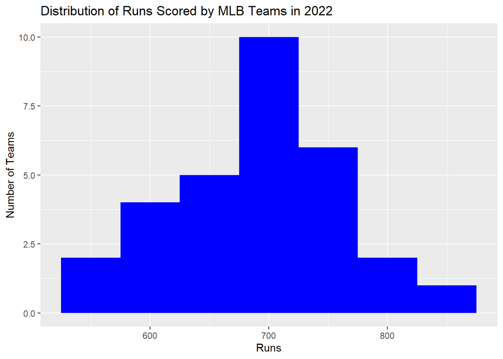

```r
teams_2022 %>% # Take the 2022 team data
  ggplot(aes(x = R)) + # Feed it to ggplot, and set the X "aesthetic" to be runs (that is, make the x-axis be runs)
                       # Notice this line ends with a `+`, not a `%>%`. This is because we are "adding" layers to the plot

  geom_histogram(binwidth = 50,   # A "geom" is a "layer" you add to the plot.
                 fill = "blue") + # It's roughly equivalent to the graph type you want to make.
                                  # For a histogram you can manually specify the width of the bins you want as we did here,
                                  # or the number of bins with e.g. bins = 10.
                                  # You can also set the color with `fill=`.
                                  # You may have more than one layer (e.g. put down scatterplot points, then overlay a line).


  labs(x = "Runs", # Change the x-axis label
       y = "Number of Teams", # Change y-axis label
       title = "Distribution of Runs Scored by MLB Teams in 2022") # Add an overall BRIEF but DESCRIPTIVE title to the chart
```

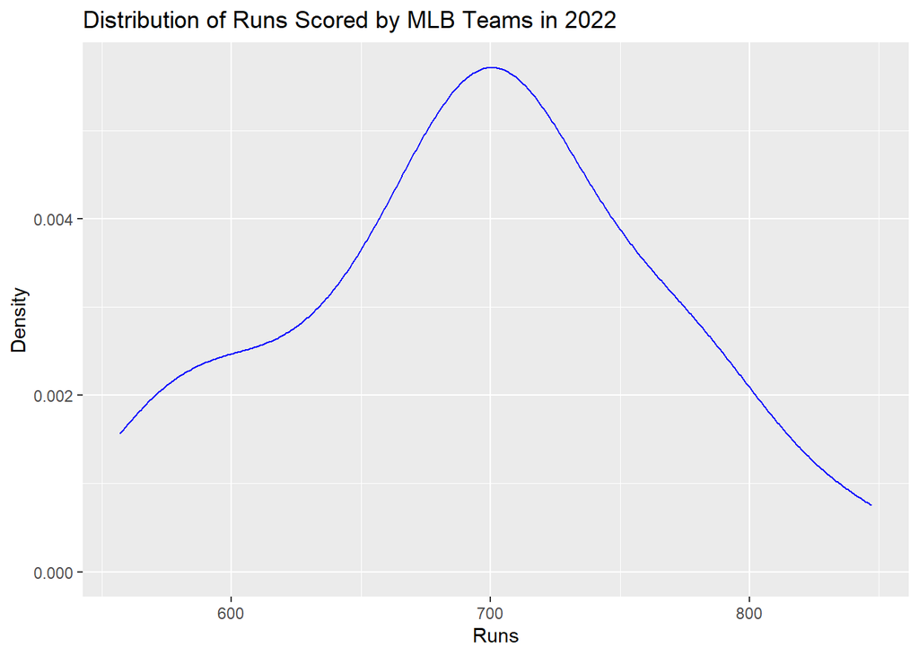

```r
teams_2022 %>%
  ggplot(aes(x = R)) +

  geom_density(color = "blue") + # Here because we wanted a different graph type we simply changed the geom
                                 # Note `color` and `fill` are different.
                                 # `color` deals with lines and outlines.
                                 # `fill` deals with filling shapes.
                                 # Try adding a `fill` to this density plot. Then try changing the `fill` to `color` in
                                 # the histogram above.


  labs(x = "Runs",
       y = "Density", # No longer shows number of teams, just "density"
       title = "Distribution of Runs Scored by MLB Teams in 2022")
```

**Lab Activity 10**:

1. How would you describe the distribution of runs scored by team in 2022?
2. What are the strengths and weaknesses of the histogram and density plot above? What does one show that the other doesn’t? Which do you prefer?
3. Alter either plot above to show the distribution of doubles rather than runs.
4. Note `color` and `fill` are different. `color` deals with lines and outlines. `fill` deals with filling shapes. Try adding a `fill` to the density plot. Then try changing the `fill` to `color` in the histogram.
5. Is there any other variable you’d like to see the distribution of?

Just like with other code, you can always save these results to a plot object using `<-`. To print the plot you then simply type the object name, just like to print a data frame or another object’s value.